# Progetto di Foundations of Probability and Statistics: BodyFat

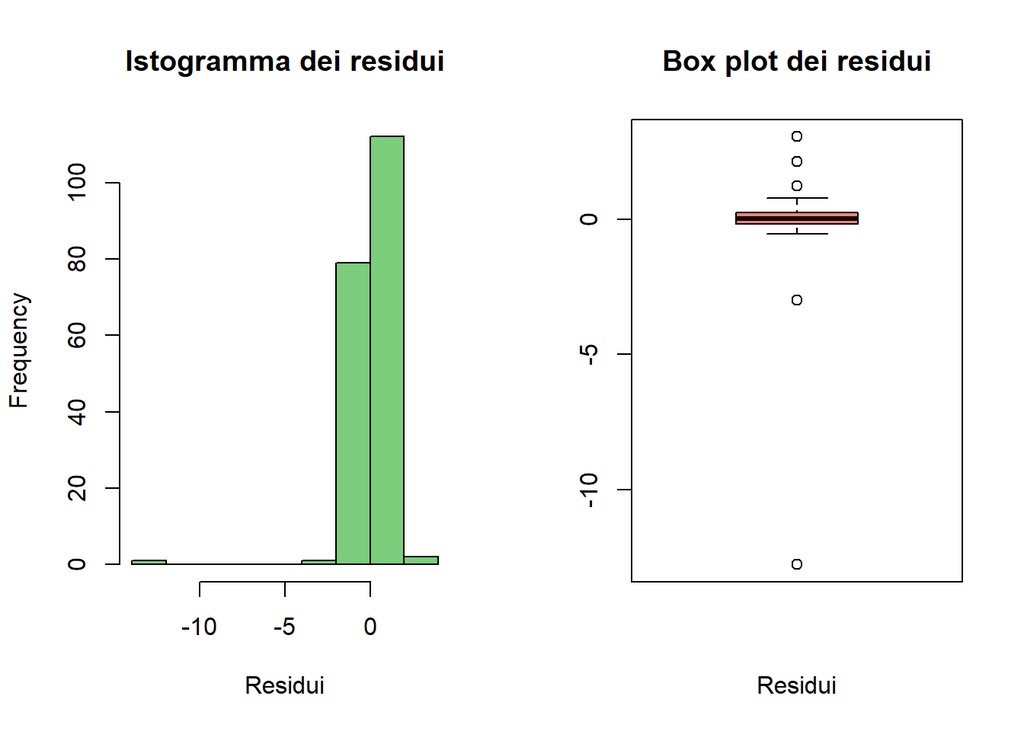

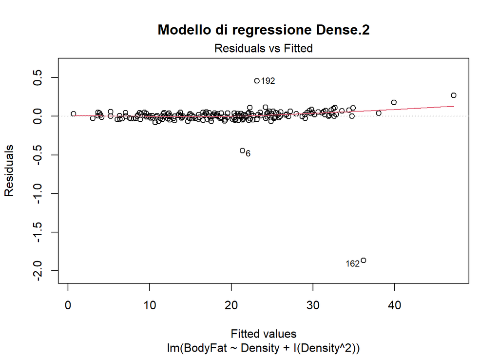

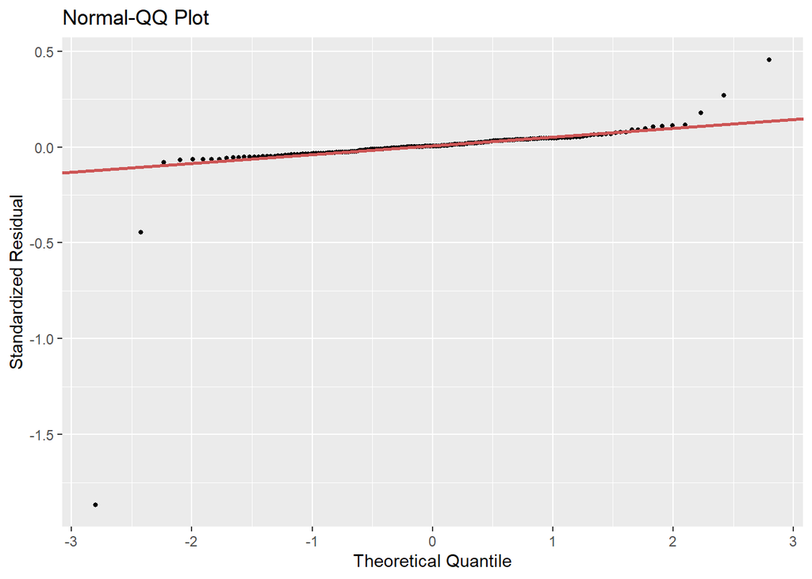

Il grafico dei residui è significativamente migliorato. Ciò nonostante, analizzando anche il box plot dei residui, notiamo la presenza di qualche valore anomalo. Rimuoviamoli e fittiamo di nuovo il modello.

```
##
## Call:
## lm(formula = BodyFat ~ Density + I(Density^2), data = bodyfat.train.density)
##
## Residuals:
##      Min       1Q   Median       3Q      Max
## -0.08044 -0.02941 -0.00043  0.02557  0.44614
##
## Coefficients:
##               Estimate Std. Error t value Pr(>|t|)
## (Intercept)    954.141      8.671  110.04   <2e-16 ***
## Density      -1326.975     16.457  -80.64   <2e-16 ***
## I(Density^2)   417.797      7.807   53.52   <2e-16 ***
## ---
## Signif. codes:  0 '***' 0.001 '**' 0.01 '*' 0.05 '.' 0.1 ' ' 1
##
## Residual standard error: 0.04867 on 184 degrees of freedom
## Multiple R-squared:      1,  Adjusted R-squared:      1
## F-statistic: 2.79e+06 on 2 and 184 DF,  p-value: < 2.2e-16
```

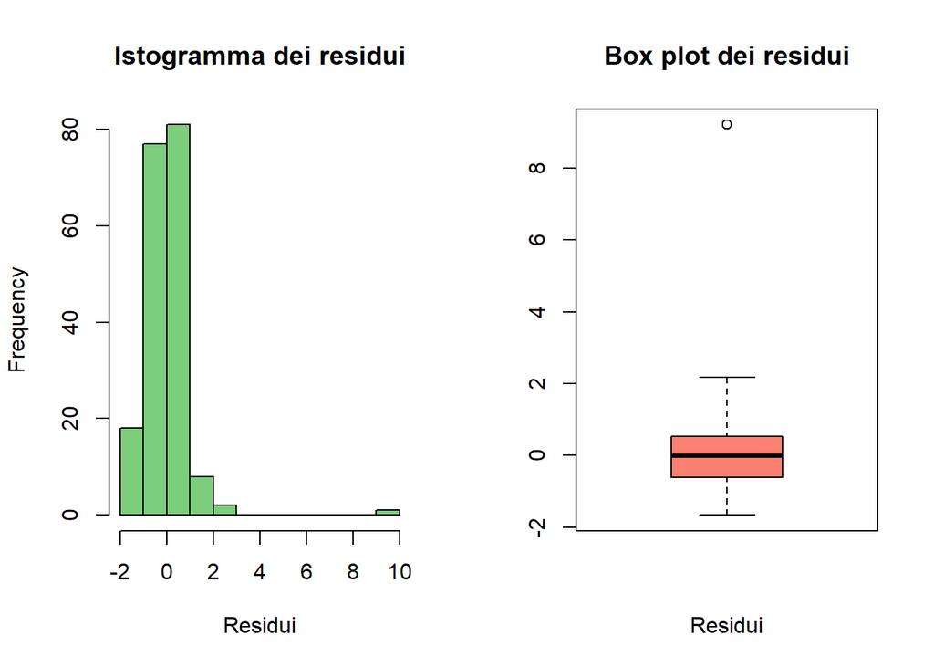

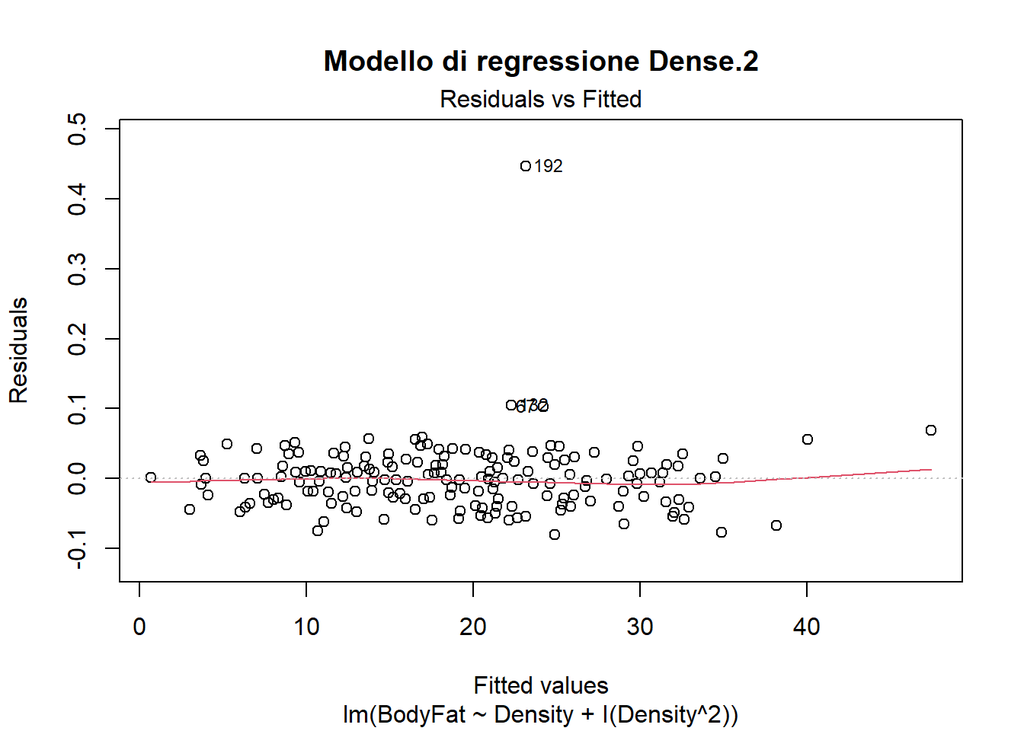

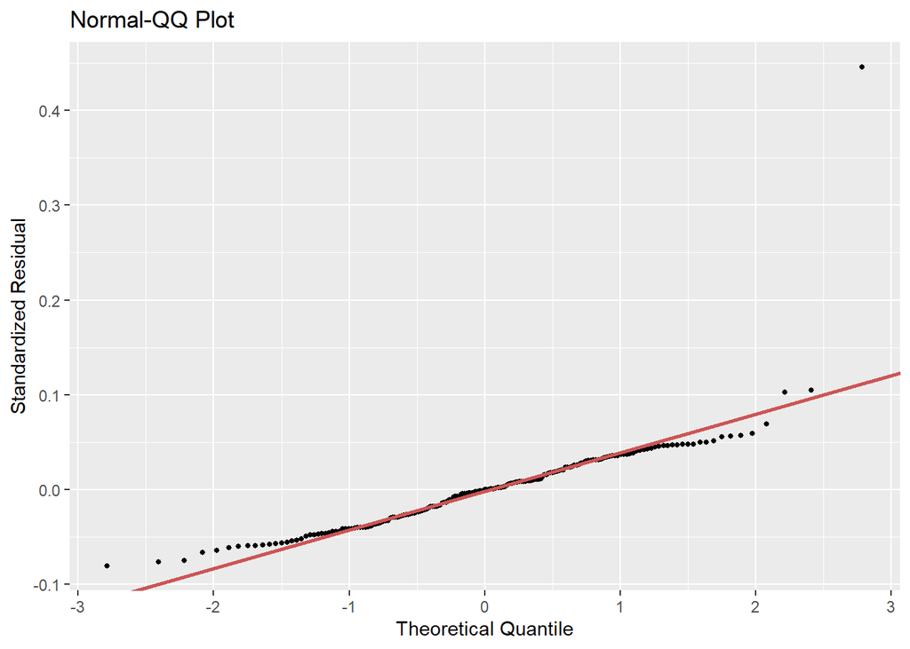

Rimuovendo i valori anomali, otteniamo un indice R-quadro pari al 100%. Ciò significa che *Density* riesce a spiegare la totalità della variabile target *BodyFat*. Il grafico dei residui risulta ora molto centrato intorno allo zero. Per questi motivi ci aspettiamo un’alta capacità predittiva.

```
## [1] "Valori correttamente predetti con il 1 % di margine:"
## [1] "49/50"
## [1] "Percentuale: 98"
```

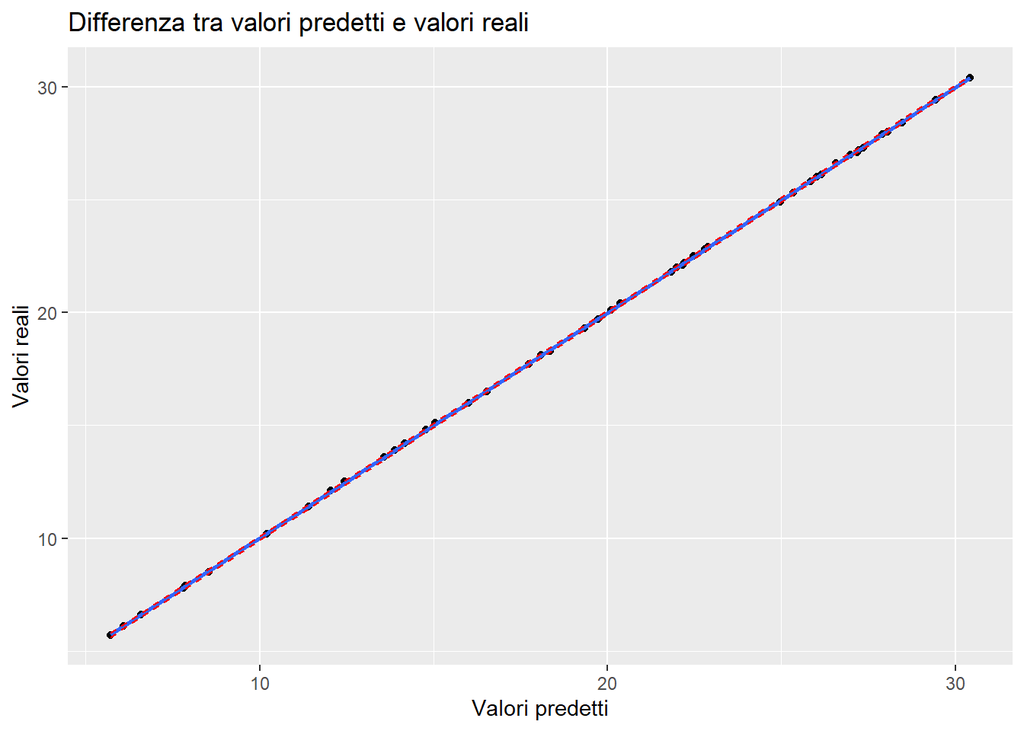

La capacità predittiva è pressoché del 100%, come si evince anche dal grafico, in cui i valori predetti coincidono quasi perfettamente coi valori reali.

# 6 CONCLUSIONI

Riassumendo, è stata effettuata l’analisi descrittiva del dataset BodyFat, dalla quale si è verificato come la percentuale di bodyfat sia dipendente in media dalla fascia di età di appartenenza di un individuo. Inoltre, è stato costruito un modello di regressione lineare per predirre la percentuale di grasso corporeo. Il modello così costruito è stato poi confrontato col modello avente come unica covariata la variabile *Density*. Quest’ultimo presenta ovviamente una precisione molto alta, ma fa uso di un regressore (*Density*) più difficile da ottenere rispetto alle misurazioni corporee comuni, meno precise. Il modello di regressione avente quest’ultime come covariate risulta tuttavia abbastanza affidabile, con un indice R-quadro di circa il 73% e, soprattutto, una capacità predittiva dell’86% (con una tolleranza del 25%). In conclusione, tale modello rappresenta un buon compromesso tra prestazioni e complessità delle misurazioni.

# APPENDICE: FUNZIONI IMPLEMENTATE

Ai fini di una migliore comprensione ed ottimizzazione del codice sono state implementate varie funzioni. Nello specifico:

- *udm*: Funzione prettamente accessoria che associa ad ogni variabile nei grafici la propria unità di misura.
- Conversione delle unità di misura:
  - *from_inches_to_cm*: Pollici -> Centimetri.
  - *from_lbs_to_kg*: Libbre -> Chilogrammi.
- *date_scatter*: Funzione che prende in input una variabile e restituisce una grob con le informazioni necessarie a creare lo Scatter plot della variabile rispetto a quella target *BodyFat*.
- *date_box*: Funzione che prende in input una variabile e restituisce una grob con le informazioni necessarie a creare il Box plot della variabile.
- *partial_correlation*: Funzione che restituisce la correlazione parziale tra x e y, dato z.
- *graphs_*: Funzione che, dato un modello, restituisce i grafici concernenti l’analisi del modello lineare con annessi residui.
- *prediction*: Funzione che restituisce l’*accuracy* del modello passato come parametro. In particolare, l’*accuracy* è calcolata considerando il rapporto tra previsioni giuste e previsioni totali, dove con “giuste” intendiamo un margine di errore pari ad *err*.